# SeqMonk Vistory Report

## Project Summary

### Basic Project Info

| Parameter | Value |
| --- | --- |
| Project Name | pluripotency_exit_EpiLC_DNMT_ATAC.smk |
| Vistory Name | pluripotency_exit_EpiLC_DNMT_ATAC_pmQC.smv |
| Genome | Mus musculus GRCm38_v95 |
| SeqMonk Version | 1.45.3.devel |

### Data Sets

| Name | File Name | Reads | Import Options |
| --- | --- | --- | --- |
| lane7005_AAGAGGCA_Dnmt13_KO_Day_0_2_L001_R1_trimmed_GRCm38_bowtie2.bam | /bi/seqfac/seqfac/191007_D00436_0478_BHY7NMBCX2/Aligned/Project_HY7NMBCX2/Sample_lane1/lane7005_AAGAGGCA_Dnmt13_KO_Day_0_2_L001_R1_trimmed_GRCm38_bowtie2.bam | 6603687 | Library type Single End Dedup=No MAPQ>=20 Primary alignments only. Extend reads by 250 |
| lane7005_ACCACTGT_Dnmt13_KO_Day_1_2_L001_R1_trimmed_GRCm38_bowtie2.bam | /bi/seqfac/seqfac/191007_D00436_0478_BHY7NMBCX2/Aligned/Project_HY7NMBCX2/Sample_lane1/lane7005_ACCACTGT_Dnmt13_KO_Day_1_2_L001_R1_trimmed_GRCm38_bowtie2.bam | 4078703 | Library type Single End Dedup=No MAPQ>=20 Primary alignments only. Extend reads by 250 |
| lane7005_AGGCAGAA_Dnmt13_WT_Day_0_3_L001_R1_trimmed_GRCm38_bowtie2.bam | /bi/seqfac/seqfac/191007_D00436_0478_BHY7NMBCX2/Aligned/Project_HY7NMBCX2/Sample_lane1/lane7005_AGGCAGAA_Dnmt13_WT_Day_0_3_L001_R1_trimmed_GRCm38_bowtie2.bam | 8295584 | Library type Single End Dedup=No MAPQ>=20 Primary alignments only. Extend reads by 250 |
| lane7005_CAGAGAGG_Dnmt13_WT_Day_2_2_L001_R1_trimmed_GRCm38_bowtie2.bam | /bi/seqfac/seqfac/191007_D00436_0478_BHY7NMBCX2/Aligned/Project_HY7NMBCX2/Sample_lane1/lane7005_CAGAGAGG_Dnmt13_WT_Day_2_2_L001_R1_trimmed_GRCm38_bowtie2.bam | 6263183 | Library type Single End Dedup=No MAPQ>=20 Primary alignments only. Extend reads by 250 |
| lane7005_CCGTTTGT_Dnmt13_KO_Day_2_1_L001_R1_trimmed_GRCm38_bowtie2.bam | /bi/seqfac/seqfac/191007_D00436_0478_BHY7NMBCX2/Aligned/Project_HY7NMBCX2/Sample_lane1/lane7005_CCGTTTGT_Dnmt13_KO_Day_2_1_L001_R1_trimmed_GRCm38_bowtie2.bam | 7554053 | Library type Single End Dedup=No MAPQ>=20 Primary alignments only. Extend reads by 250 |
| lane7005_CGAGGCTG_Dnmt13_KO_Day_0_1_L001_R1_trimmed_GRCm38_bowtie2.bam | /bi/seqfac/seqfac/191007_D00436_0478_BHY7NMBCX2/Aligned/Project_HY7NMBCX2/Sample_lane1/lane7005_CGAGGCTG_Dnmt13_KO_Day_0_1_L001_R1_trimmed_GRCm38_bowtie2.bam | 6462225 | Library type Single End Dedup=No MAPQ>=20 Primary alignments only. Extend reads by 250 |
| lane7005_CGTACTAG_Dnmt13_WT_Day_0_2_L001_R1_trimmed_GRCm38_bowtie2.bam | /bi/seqfac/seqfac/191007_D00436_0478_BHY7NMBCX2/Aligned/Project_HY7NMBCX2/Sample_lane1/lane7005_CGTACTAG_Dnmt13_WT_Day_0_2_L001_R1_trimmed_GRCm38_bowtie2.bam | 6435280 | Library type Single End Dedup=No MAPQ>=20 Primary alignments only. Extend reads by 250 |
| lane7005_CTCTCTAC_Dnmt13_WT_Day_2_1_L001_R1_trimmed_GRCm38_bowtie2.bam | /bi/seqfac/seqfac/191007_D00436_0478_BHY7NMBCX2/Aligned/Project_HY7NMBCX2/Sample_lane1/lane7005_CTCTCTAC_Dnmt13_WT_Day_2_1_L001_R1_trimmed_GRCm38_bowtie2.bam | 7195699 | Library type Single End Dedup=No MAPQ>=20 Primary alignments only. Extend reads by 250 |
| lane7005_GAGGGGTT_Dnmt13_KO_Day_2_3_L001_R1_trimmed_GRCm38_bowtie2.bam | /bi/seqfac/seqfac/191007_D00436_0478_BHY7NMBCX2/Aligned/Project_HY7NMBCX2/Sample_lane1/lane7005_GAGGGGTT_Dnmt13_KO_Day_2_3_L001_R1_trimmed_GRCm38_bowtie2.bam | 6457724 | Library type Single End Dedup=No MAPQ>=20 Primary alignments only. Extend reads by 250 |
| lane7005_GCTACGCT_Dnmt13_WT_Day_2_3_L001_R1_trimmed_GRCm38_bowtie2.bam | /bi/seqfac/seqfac/191007_D00436_0478_BHY7NMBCX2/Aligned/Project_HY7NMBCX2/Sample_lane1/lane7005_GCTACGCT_Dnmt13_WT_Day_2_3_L001_R1_trimmed_GRCm38_bowtie2.bam | 5706778 | Library type Single End Dedup=No MAPQ>=20 Primary alignments only. Extend reads by 250 |
| lane7005_GGACTCCT_Dnmt13_WT_Day_1_2_L001_R1_trimmed_GRCm38_bowtie2.bam | /bi/seqfac/seqfac/191007_D00436_0478_BHY7NMBCX2/Aligned/Project_HY7NMBCX2/Sample_lane1/lane7005_GGACTCCT_Dnmt13_WT_Day_1_2_L001_R1_trimmed_GRCm38_bowtie2.bam | 9489631 | Library type Single End Dedup=No MAPQ>=20 Primary alignments only. Extend reads by 250 |
| lane7005_GTAGAGGA_Dnmt13_KO_Day_0_3_L001_R1_trimmed_GRCm38_bowtie2.bam | /bi/seqfac/seqfac/191007_D00436_0478_BHY7NMBCX2/Aligned/Project_HY7NMBCX2/Sample_lane1/lane7005_GTAGAGGA_Dnmt13_KO_Day_0_3_L001_R1_trimmed_GRCm38_bowtie2.bam | 6343782 | Library type Single End Dedup=No MAPQ>=20 Primary alignments only. Extend reads by 250 |
| lane7005_GTCGTGAT_Dnmt13_KO_Day_1_1_L001_R1_trimmed_GRCm38_bowtie2.bam | /bi/seqfac/seqfac/191007_D00436_0478_BHY7NMBCX2/Aligned/Project_HY7NMBCX2/Sample_lane1/lane7005_GTCGTGAT_Dnmt13_KO_Day_1_1_L001_R1_trimmed_GRCm38_bowtie2.bam | 6459710 | Library type Single End Dedup=No MAPQ>=20 Primary alignments only. Extend reads by 250 |
| lane7005_TAAGGCGA_Dnmt13_WT_Day_0_1_L001_R1_trimmed_GRCm38_bowtie2.bam | /bi/seqfac/seqfac/191007_D00436_0478_BHY7NMBCX2/Aligned/Project_HY7NMBCX2/Sample_lane1/lane7005_TAAGGCGA_Dnmt13_WT_Day_0_1_L001_R1_trimmed_GRCm38_bowtie2.bam | 7904469 | Library type Single End Dedup=No MAPQ>=20 Primary alignments only. Extend reads by 250 |
| lane7005_TAGGCATG_Dnmt13_WT_Day_1_3_L001_R1_trimmed_GRCm38_bowtie2.bam | /bi/seqfac/seqfac/191007_D00436_0478_BHY7NMBCX2/Aligned/Project_HY7NMBCX2/Sample_lane1/lane7005_TAGGCATG_Dnmt13_WT_Day_1_3_L001_R1_trimmed_GRCm38_bowtie2.bam | 4072943 | Library type Single End Dedup=No MAPQ>=20 Primary alignments only. Extend reads by 250 |
| lane7005_TCCTGAGC_Dnmt13_WT_Day_1_1_L001_R1_trimmed_GRCm38_bowtie2.bam | /bi/seqfac/seqfac/191007_D00436_0478_BHY7NMBCX2/Aligned/Project_HY7NMBCX2/Sample_lane1/lane7005_TCCTGAGC_Dnmt13_WT_Day_1_1_L001_R1_trimmed_GRCm38_bowtie2.bam | 7773108 | Library type Single End Dedup=No MAPQ>=20 Primary alignments only. Extend reads by 250 |
| lane7005_TGCTGGGT_Dnmt13_KO_Day_2_2_L001_R1_trimmed_GRCm38_bowtie2.bam | /bi/seqfac/seqfac/191007_D00436_0478_BHY7NMBCX2/Aligned/Project_HY7NMBCX2/Sample_lane1/lane7005_TGCTGGGT_Dnmt13_KO_Day_2_2_L001_R1_trimmed_GRCm38_bowtie2.bam | 6011131 | Library type Single End Dedup=No MAPQ>=20 Primary alignments only. Extend reads by 250 |
| lane7005_TGGATCTG_Dnmt13_KO_Day_1_3_L001_R1_trimmed_GRCm38_bowtie2.bam | /bi/seqfac/seqfac/191007_D00436_0478_BHY7NMBCX2/Aligned/Project_HY7NMBCX2/Sample_lane1/lane7005_TGGATCTG_Dnmt13_KO_Day_1_3_L001_R1_trimmed_GRCm38_bowtie2.bam | 5873800 | Library type Single End Dedup=No MAPQ>=20 Primary alignments only. Extend reads by 250 |

## Data set renaming & Creating Groups

Data Set Renamed

lane7005_AAGAGGCA_Dnmt13_KO_Day_0_2_L001_R1_trimmed_GRCm38_bowtie2.bam changed to lane7005_AAGAGGCA_Dnmt13_KO_Day_0_2_L001_R1_trimmed_GRCm38_bowtie2.bam

Data Set Renamed

lane7005_ACCACTGT_Dnmt13_KO_Day_1_2_L001_R1_trimmed_GRCm38_bowtie2.bam changed to lane7005_ACCACTGT_Dnmt13_KO_Day_1_2_L001_R1_trimmed_GRCm38_bowtie2.bam

Data Set Renamed

lane7005_AGGCAGAA_Dnmt13_WT_Day_0_3_L001_R1_trimmed_GRCm38_bowtie2.bam changed to lane7005_AGGCAGAA_Dnmt13_WT_Day_0_3_L001_R1_trimmed_GRCm38_bowtie2.bam

Data Set Renamed

lane7005_CAGAGAGG_Dnmt13_WT_Day_2_2_L001_R1_trimmed_GRCm38_bowtie2.bam changed to lane7005_CAGAGAGG_Dnmt13_WT_Day_2_2_L001_R1_trimmed_GRCm38_bowtie2.bam

Data Set Renamed

lane7005_CCGTTTGT_Dnmt13_KO_Day_2_1_L001_R1_trimmed_GRCm38_bowtie2.bam changed to lane7005_CCGTTTGT_Dnmt13_KO_Day_2_1_L001_R1_trimmed_GRCm38_bowtie2.bam

Data Set Renamed

lane7005_CGAGGCTG_Dnmt13_KO_Day_0_1_L001_R1_trimmed_GRCm38_bowtie2.bam changed to lane7005_CGAGGCTG_Dnmt13_KO_Day_0_1_L001_R1_trimmed_GRCm38_bowtie2.bam

Data Set Renamed

lane7005_CGTACTAG_Dnmt13_WT_Day_0_2_L001_R1_trimmed_GRCm38_bowtie2.bam changed to lane7005_CGTACTAG_Dnmt13_WT_Day_0_2_L001_R1_trimmed_GRCm38_bowtie2.bam

Data Set Renamed

lane7005_CTCTCTAC_Dnmt13_WT_Day_2_1_L001_R1_trimmed_GRCm38_bowtie2.bam changed to lane7005_CTCTCTAC_Dnmt13_WT_Day_2_1_L001_R1_trimmed_GRCm38_bowtie2.bam

Data Set Renamed

lane7005_GAGGGGTT_Dnmt13_KO_Day_2_3_L001_R1_trimmed_GRCm38_bowtie2.bam changed to lane7005_GAGGGGTT_Dnmt13_KO_Day_2_3_L001_R1_trimmed_GRCm38_bowtie2.bam

Data Set Renamed

lane7005_GCTACGCT_Dnmt13_WT_Day_2_3_L001_R1_trimmed_GRCm38_bowtie2.bam changed to lane7005_GCTACGCT_Dnmt13_WT_Day_2_3_L001_R1_trimmed_GRCm38_bowtie2.bam

Data Set Renamed

lane7005_GGACTCCT_Dnmt13_WT_Day_1_2_L001_R1_trimmed_GRCm38_bowtie2.bam changed to lane7005_GGACTCCT_Dnmt13_WT_Day_1_2_L001_R1_trimmed_GRCm38_bowtie2.bam

Data Set Renamed

lane7005_GTAGAGGA_Dnmt13_KO_Day_0_3_L001_R1_trimmed_GRCm38_bowtie2.bam changed to lane7005_GTAGAGGA_Dnmt13_KO_Day_0_3_L001_R1_trimmed_GRCm38_bowtie2.bam

Data Set Renamed

lane7005_GTCGTGAT_Dnmt13_KO_Day_1_1_L001_R1_trimmed_GRCm38_bowtie2.bam changed to lane7005_GTCGTGAT_Dnmt13_KO_Day_1_1_L001_R1_trimmed_GRCm38_bowtie2.bam

Data Set Renamed

lane7005_TAAGGCGA_Dnmt13_WT_Day_0_1_L001_R1_trimmed_GRCm38_bowtie2.bam changed to lane7005_TAAGGCGA_Dnmt13_WT_Day_0_1_L001_R1_trimmed_GRCm38_bowtie2.bam

Data Set Renamed

lane7005_TAGGCATG_Dnmt13_WT_Day_1_3_L001_R1_trimmed_GRCm38_bowtie2.bam changed to lane7005_TAGGCATG_Dnmt13_WT_Day_1_3_L001_R1_trimmed_GRCm38_bowtie2.bam

Data Set Renamed

lane7005_TCCTGAGC_Dnmt13_WT_Day_1_1_L001_R1_trimmed_GRCm38_bowtie2.bam changed to lane7005_TCCTGAGC_Dnmt13_WT_Day_1_1_L001_R1_trimmed_GRCm38_bowtie2.bam

Data Set Renamed

lane7005_TGCTGGGT_Dnmt13_KO_Day_2_2_L001_R1_trimmed_GRCm38_bowtie2.bam changed to lane7005_TGCTGGGT_Dnmt13_KO_Day_2_2_L001_R1_trimmed_GRCm38_bowtie2.bam

Data Set Renamed

lane7005_TGGATCTG_Dnmt13_KO_Day_1_3_L001_R1_trimmed_GRCm38_bowtie2.bam changed to lane7005_TGGATCTG_Dnmt13_KO_Day_1_3_L001_R1_trimmed_GRCm38_bowtie2.bam

Data Set Renamed

lane7005_AAGAGGCA_Dnmt13_KO_Day_0_2_L001_R1_trimmed_GRCm38_bowtie2.bam changed to ATAC_Dnmt13_KO_Day_0_2_L001_R1_trimmed_GRCm38_bowtie2.bam

Data Set Renamed

lane7005_ACCACTGT_Dnmt13_KO_Day_1_2_L001_R1_trimmed_GRCm38_bowtie2.bam changed to ATAC_Dnmt13_KO_Day_1_2_L001_R1_trimmed_GRCm38_bowtie2.bam

Data Set Renamed

lane7005_AGGCAGAA_Dnmt13_WT_Day_0_3_L001_R1_trimmed_GRCm38_bowtie2.bam changed to ATAC_Dnmt13_WT_Day_0_3_L001_R1_trimmed_GRCm38_bowtie2.bam

Data Set Renamed

lane7005_CAGAGAGG_Dnmt13_WT_Day_2_2_L001_R1_trimmed_GRCm38_bowtie2.bam changed to ATAC_Dnmt13_WT_Day_2_2_L001_R1_trimmed_GRCm38_bowtie2.bam

Data Set Renamed

lane7005_CCGTTTGT_Dnmt13_KO_Day_2_1_L001_R1_trimmed_GRCm38_bowtie2.bam changed to ATAC_Dnmt13_KO_Day_2_1_L001_R1_trimmed_GRCm38_bowtie2.bam

Data Set Renamed

lane7005_CGAGGCTG_Dnmt13_KO_Day_0_1_L001_R1_trimmed_GRCm38_bowtie2.bam changed to ATAC_Dnmt13_KO_Day_0_1_L001_R1_trimmed_GRCm38_bowtie2.bam

Data Set Renamed

lane7005_CGTACTAG_Dnmt13_WT_Day_0_2_L001_R1_trimmed_GRCm38_bowtie2.bam changed to ATAC_Dnmt13_WT_Day_0_2_L001_R1_trimmed_GRCm38_bowtie2.bam

Data Set Renamed

lane7005_CTCTCTAC_Dnmt13_WT_Day_2_1_L001_R1_trimmed_GRCm38_bowtie2.bam changed to ATAC_Dnmt13_WT_Day_2_1_L001_R1_trimmed_GRCm38_bowtie2.bam

Data Set Renamed

lane7005_GAGGGGTT_Dnmt13_KO_Day_2_3_L001_R1_trimmed_GRCm38_bowtie2.bam changed to ATAC_Dnmt13_KO_Day_2_3_L001_R1_trimmed_GRCm38_bowtie2.bam

Data Set Renamed

lane7005_GCTACGCT_Dnmt13_WT_Day_2_3_L001_R1_trimmed_GRCm38_bowtie2.bam changed to ATAC_Dnmt13_WT_Day_2_3_L001_R1_trimmed_GRCm38_bowtie2.bam

Data Set Renamed

lane7005_GGACTCCT_Dnmt13_WT_Day_1_2_L001_R1_trimmed_GRCm38_bowtie2.bam changed to ATAC_Dnmt13_WT_Day_1_2_L001_R1_trimmed_GRCm38_bowtie2.bam

Data Set Renamed

lane7005_GTAGAGGA_Dnmt13_KO_Day_0_3_L001_R1_trimmed_GRCm38_bowtie2.bam changed to ATAC_Dnmt13_KO_Day_0_3_L001_R1_trimmed_GRCm38_bowtie2.bam

Data Set Renamed

lane7005_GTCGTGAT_Dnmt13_KO_Day_1_1_L001_R1_trimmed_GRCm38_bowtie2.bam changed to ATAC_Dnmt13_KO_Day_1_1_L001_R1_trimmed_GRCm38_bowtie2.bam

Data Set Renamed

lane7005_TAAGGCGA_Dnmt13_WT_Day_0_1_L001_R1_trimmed_GRCm38_bowtie2.bam changed to ATAC_Dnmt13_WT_Day_0_1_L001_R1_trimmed_GRCm38_bowtie2.bam

Data Set Renamed

lane7005_TAGGCATG_Dnmt13_WT_Day_1_3_L001_R1_trimmed_GRCm38_bowtie2.bam changed to ATAC_Dnmt13_WT_Day_1_3_L001_R1_trimmed_GRCm38_bowtie2.bam

Data Set Renamed

lane7005_TCCTGAGC_Dnmt13_WT_Day_1_1_L001_R1_trimmed_GRCm38_bowtie2.bam changed to ATAC_Dnmt13_WT_Day_1_1_L001_R1_trimmed_GRCm38_bowtie2.bam

Data Set Renamed

lane7005_TGCTGGGT_Dnmt13_KO_Day_2_2_L001_R1_trimmed_GRCm38_bowtie2.bam changed to ATAC_Dnmt13_KO_Day_2_2_L001_R1_trimmed_GRCm38_bowtie2.bam

Data Set Renamed

lane7005_TGGATCTG_Dnmt13_KO_Day_1_3_L001_R1_trimmed_GRCm38_bowtie2.bam changed to ATAC_Dnmt13_KO_Day_1_3_L001_R1_trimmed_GRCm38_bowtie2.bam

Data Set Renamed

ATAC_Dnmt13_KO_Day_0_2_L001_R1_trimmed_GRCm38_bowtie2.bam changed to ATAC_Dnmt13_KO_Day_0_2

Data Set Renamed

ATAC_Dnmt13_KO_Day_1_2_L001_R1_trimmed_GRCm38_bowtie2.bam changed to ATAC_Dnmt13_KO_Day_1_2

Data Set Renamed

ATAC_Dnmt13_WT_Day_0_3_L001_R1_trimmed_GRCm38_bowtie2.bam changed to ATAC_Dnmt13_WT_Day_0_3

Data Set Renamed

ATAC_Dnmt13_WT_Day_2_2_L001_R1_trimmed_GRCm38_bowtie2.bam changed to ATAC_Dnmt13_WT_Day_2_2

Data Set Renamed

ATAC_Dnmt13_KO_Day_2_1_L001_R1_trimmed_GRCm38_bowtie2.bam changed to ATAC_Dnmt13_KO_Day_2_1

Data Set Renamed

ATAC_Dnmt13_KO_Day_0_1_L001_R1_trimmed_GRCm38_bowtie2.bam changed to ATAC_Dnmt13_KO_Day_0_1

Data Set Renamed

ATAC_Dnmt13_WT_Day_0_2_L001_R1_trimmed_GRCm38_bowtie2.bam changed to ATAC_Dnmt13_WT_Day_0_2

Data Set Renamed

ATAC_Dnmt13_WT_Day_2_1_L001_R1_trimmed_GRCm38_bowtie2.bam changed to ATAC_Dnmt13_WT_Day_2_1

Data Set Renamed

ATAC_Dnmt13_KO_Day_2_3_L001_R1_trimmed_GRCm38_bowtie2.bam changed to ATAC_Dnmt13_KO_Day_2_3

Data Set Renamed

ATAC_Dnmt13_WT_Day_2_3_L001_R1_trimmed_GRCm38_bowtie2.bam changed to ATAC_Dnmt13_WT_Day_2_3

Data Set Renamed

ATAC_Dnmt13_WT_Day_1_2_L001_R1_trimmed_GRCm38_bowtie2.bam changed to ATAC_Dnmt13_WT_Day_1_2

Data Set Renamed

ATAC_Dnmt13_KO_Day_0_3_L001_R1_trimmed_GRCm38_bowtie2.bam changed to ATAC_Dnmt13_KO_Day_0_3

Data Set Renamed

ATAC_Dnmt13_KO_Day_1_1_L001_R1_trimmed_GRCm38_bowtie2.bam changed to ATAC_Dnmt13_KO_Day_1_1

Data Set Renamed

ATAC_Dnmt13_WT_Day_0_1_L001_R1_trimmed_GRCm38_bowtie2.bam changed to ATAC_Dnmt13_WT_Day_0_1

Data Set Renamed

ATAC_Dnmt13_WT_Day_1_3_L001_R1_trimmed_GRCm38_bowtie2.bam changed to ATAC_Dnmt13_WT_Day_1_3

Data Set Renamed

ATAC_Dnmt13_WT_Day_1_1_L001_R1_trimmed_GRCm38_bowtie2.bam changed to ATAC_Dnmt13_WT_Day_1_1

Data Set Renamed

ATAC_Dnmt13_KO_Day_2_2_L001_R1_trimmed_GRCm38_bowtie2.bam changed to ATAC_Dnmt13_KO_Day_2_2

Data Set Renamed

ATAC_Dnmt13_KO_Day_1_3_L001_R1_trimmed_GRCm38_bowtie2.bam changed to ATAC_Dnmt13_KO_Day_1_3

Replicate Set Created

ATAC_Dnmt13_KO_Day_0 ATAC_Dnmt13_KO_Day_0_1 ATAC_Dnmt13_KO_Day_0_2 ATAC_Dnmt13_KO_Day_0_3

Replicate Set Created

ATAC_Dnmt13_KO_Day_1 ATAC_Dnmt13_KO_Day_1_1 ATAC_Dnmt13_KO_Day_1_2 ATAC_Dnmt13_KO_Day_1_3

Replicate Set Created

ATAC_Dnmt13_KO_Day_2 ATAC_Dnmt13_KO_Day_2_1 ATAC_Dnmt13_KO_Day_2_2 ATAC_Dnmt13_KO_Day_2_3

Replicate Set Created

ATAC_Dnmt13_WT_Day_0 ATAC_Dnmt13_WT_Day_0_1 ATAC_Dnmt13_WT_Day_0_2 ATAC_Dnmt13_WT_Day_0_3

Replicate Set Created

ATAC_Dnmt13_WT_Day_1 ATAC_Dnmt13_WT_Day_1_1 ATAC_Dnmt13_WT_Day_1_2 ATAC_Dnmt13_WT_Day_1_3

Replicate Set Created

ATAC_Dnmt13_WT_Day_2 ATAC_Dnmt13_WT_Day_2_1 ATAC_Dnmt13_WT_Day_2_2 ATAC_Dnmt13_WT_Day_2_3

### Running window quantitation

New Probe Set (2725549 probes)

Running windows of size 1000 with step size 1000

Probes Quantitated

Read Count Quantitation using All Reads correcting for total count per million reads log transformed

### Cumulative Distributions

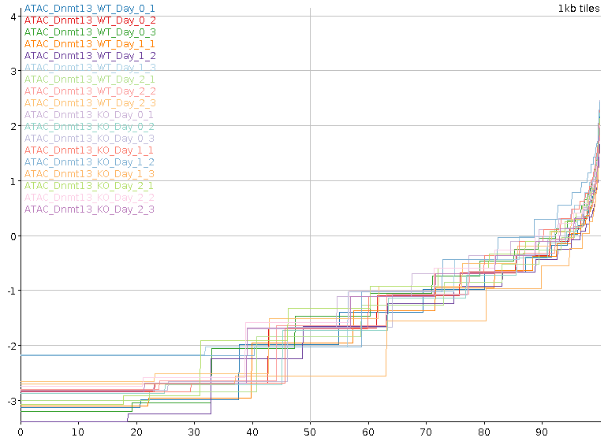

### Data Store Summary

| DataStore | Total Read Count | Forward Read Count | Reverse Read Count | Unknown Read Count | Mean Read Length | Total Read Length | Fold Coverage | Total Quantitation | Median Quantitation | Mean Quantitation | Valid Quantitations |
| --- | --- | --- | --- | --- | --- | --- | --- | --- | --- | --- | --- |
| ATAC_Dnmt13_WT_Day_0_1 | 7904469 | 3949269 | 3955200 | 0 | 298 | 2358739165 | 0.8654215980311223 | -5038518.777562784 | -1.9826686 | -1.8486253 | 2725549 |
| ATAC_Dnmt13_WT_Day_0_2 | 6435280 | 3214165 | 3221115 | 0 | 298 | 1919229657 | 0.7041655225789506 | -4692138.88761875 | -1.686003 | -1.721539 | 2725549 |
| ATAC_Dnmt13_WT_Day_0_3 | 8295584 | 4147000 | 4148584 | 0 | 298 | 2472721063 | 0.9072415659942948 | -4605709.728179067 | -1.4673811 | -1.6898283 | 2725549 |
| ATAC_Dnmt13_WT_Day_1_1 | 7773108 | 3877836 | 3895272 | 0 | 298 | 2321274131 | 0.851675673905353 | -5145094.312837571 | -1.9584917 | -1.8877277 | 2725549 |
| ATAC_Dnmt13_WT_Day_1_2 | 9489631 | 4737461 | 4752170 | 0 | 298 | 2834220614 | 1.0398757816617796 | -5340681.762780331 | -1.6613896 | -1.9594884 | 2725549 |
| ATAC_Dnmt13_WT_Day_1_3 | 4072943 | 2034985 | 2037958 | 0 | 298 | 1216803923 | 0.4464454616935988 | -3761603.1464116685 | -2.0260718 | -1.3801267 | 2725549 |
| ATAC_Dnmt13_WT_Day_2_1 | 7195699 | 3592987 | 3602712 | 0 | 298 | 2148083763 | 0.7881321133191793 | -4937615.169568609 | -1.8471348 | -1.8116039 | 2725549 |
| ATAC_Dnmt13_WT_Day_2_2 | 6263183 | 3128325 | 3134858 | 0 | 298 | 1869077009 | 0.6857645118094312 | -4704241.659865901 | -1.646896 | -1.7259794 | 2725549 |
| ATAC_Dnmt13_WT_Day_2_3 | 5706778 | 2849537 | 2857241 | 0 | 298 | 1704993693 | 0.6255623293680481 | -4242784.615774855 | -1.5126765 | -1.5566716 | 2725549 |
| ATAC_Dnmt13_KO_Day_0_1 | 6462225 | 3232859 | 3229366 | 0 | 298 | 1930492629 | 0.7082979079530748 | -4192553.3062986955 | -1.692031 | -1.5382417 | 2725549 |
| ATAC_Dnmt13_KO_Day_0_2 | 6603687 | 3304799 | 3298888 | 0 | 298 | 1970795283 | 0.7230849550955152 | -4885110.026117712 | -1.7232716 | -1.7923398 | 2725549 |
| ATAC_Dnmt13_KO_Day_0_3 | 6343782 | 3172498 | 3171284 | 0 | 298 | 1895170469 | 0.6953382044781418 | -4760287.063620113 | -1.665343 | -1.7465425 | 2725549 |
| ATAC_Dnmt13_KO_Day_1_1 | 6459710 | 3228865 | 3230845 | 0 | 298 | 1928558610 | 0.7075883162193052 | -4565574.1212581545 | -1.6914694 | -1.6751026 | 2725549 |
| ATAC_Dnmt13_KO_Day_1_2 | 4078703 | 2035874 | 2042829 | 0 | 298 | 1217627803 | 0.446747743334895 | -3708263.963364454 | -2.0281105 | -1.3605567 | 2725549 |
| ATAC_Dnmt13_KO_Day_1_3 | 5873800 | 2929460 | 2944340 | 0 | 299 | 1757587742 | 0.6448590903698128 | -5575165.583618002 | -2.554294 | -2.0455203 | 2725549 |
| ATAC_Dnmt13_KO_Day_2_1 | 7554053 | 3775877 | 3778176 | 0 | 298 | 2253796121 | 0.8269179863608042 | -4240913.53544195 | -1.3322885 | -1.5559851 | 2725549 |
| ATAC_Dnmt13_KO_Day_2_2 | 6011131 | 3005657 | 3005474 | 0 | 298 | 1796163722 | 0.6590126206764233 | -4105289.3457592567 | -1.5876365 | -1.5062248 | 2725549 |
| ATAC_Dnmt13_KO_Day_2_3 | 6457724 | 3228249 | 3229475 | 0 | 299 | 1930919380 | 0.7084544829308687 | -4407235.808466345 | -1.6910257 | -1.6170084 | 2725549 |

Slightly unbalanced read counts, watch when peak calling.

### Data Store Similarity

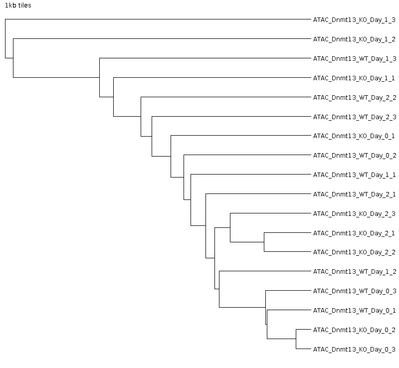

Could be prettier ....

New Probe List: Value above 0 (226605 probes)

[Probe Values Filter] Filter on probes in 1kb tiles where at least 1 of ATAC_Dnmt13_KO_Day_0 , ATAC_Dnmt13_KO_Day_1 , ATAC_Dnmt13_KO_Day_2 , ATAC_Dnmt13_WT_Day_0 , ATAC_Dnmt13_WT_Day_1 , ATAC_Dnmt13_WT_Day_2 had a value above 0.0. Quantitation was Read Count Quantitation using All Reads correcting for total count per million reads log transformed

Probe List Renamed

Probe list Value above 0 renamed to Value above 0 in any

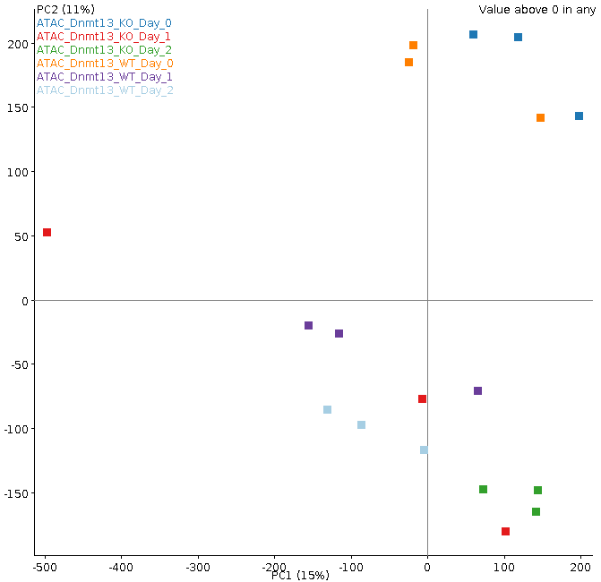

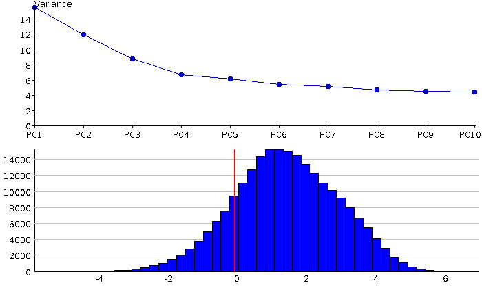

### Duplication

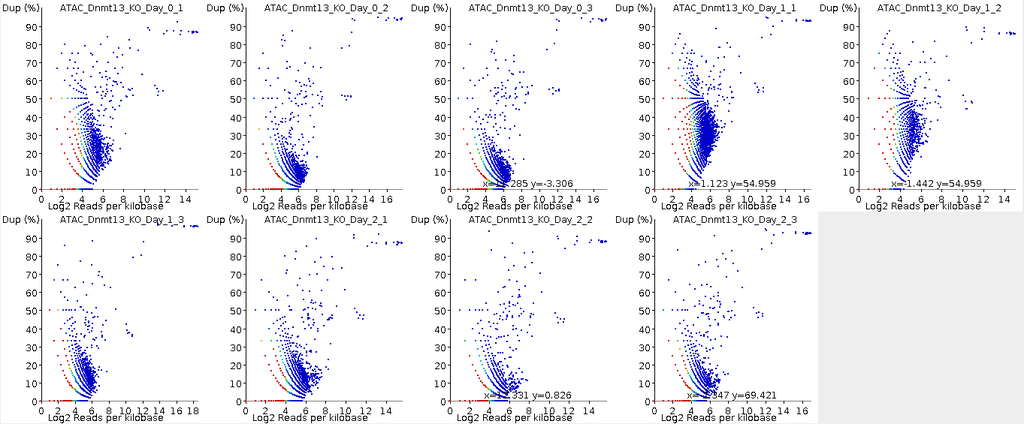

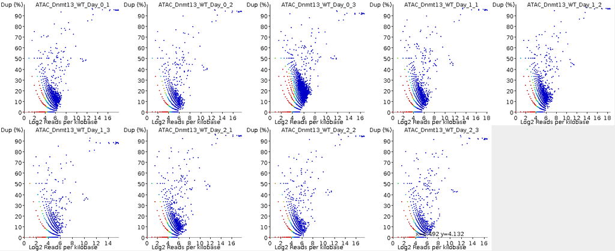

There is some variation in duplication between replicates, but it's not really enough to explain the difference in PC1 or in the tree.

A bit hard to say, but there may overall not be that much difference between the sample groups.

New Probe List: Value below 4 in all (2725452 probes)

[Probe Values Filter] Filter on probes in 1kb tiles where exactly 6 of ATAC_Dnmt13_KO_Day_0 , ATAC_Dnmt13_KO_Day_1 , ATAC_Dnmt13_KO_Day_2 , ATAC_Dnmt13_WT_Day_0 , ATAC_Dnmt13_WT_Day_1 , ATAC_Dnmt13_WT_Day_2 had a value below 4.0. Quantitation was Read Count Quantitation using All Reads correcting for total count per million reads log transformed

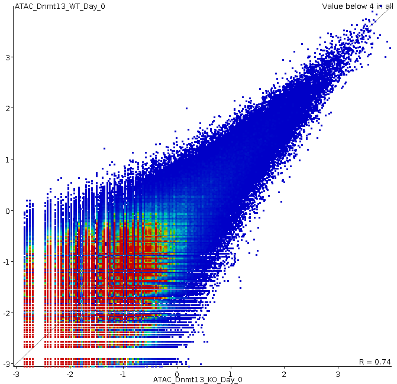

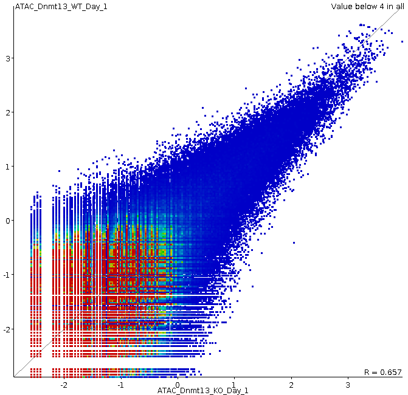

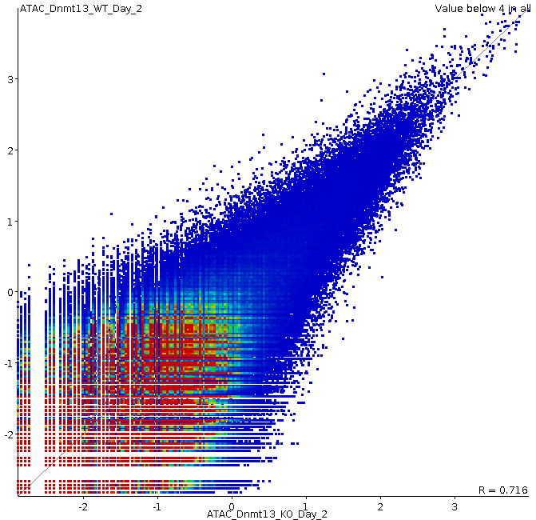